# Analysis Plan for Kepler Data

Aliaksandr Hubin

```r
#devtools::install_github("https://github.com/jonlachmann/GMJMCMC/tree/stratos")
library(FBMS)
library(tidyverse)
library(DataExplorer)
#setwd("Task_Kepler")
```

# Load the data and perform EDA

```r
data = read.csv("https://raw.githubusercontent.com/OpenExoplanetCatalogue/oec_tables/master/comma_separated/open_exoplanet_catalogue.txt")


head(data)
```

|  | name | binaryflag | mass | radius | period | semimajoraxis | eccentricity | periastron | longitude | ascendingnode | inclination | temperature | age | discoverymethod | discoveryyear | lastupdate | system_rightascension | system_declination | system_distance | hoststar_mass | hoststar_radius | hoststar_metallicity | hoststar_temperature | hoststar_age | list |
| --- | --- | --- | --- | --- | --- | --- | --- | --- | --- | --- | --- | --- | --- | --- | --- | --- | --- | --- | --- | --- | --- | --- | --- | --- | --- |
| 1 | Kepler-1032 b | 0 | NA | 0.167 | 3.290118 | NA | NA | NA | NA | NA | NA | NA | NA | transit | 2016 | 16/05/10 | 19 19 43.4040 | +40 05 51.8400 | 683.854 | 0.770 | 0.71 | 0.16 | 4647 | NA | Confirmed planets |
| 2 | HD 154857 b | 0 | 2.24 | NA | 408.600000 | 1.291 | 0.46 | 57 | NA | NA | NA | 336 | NA | RV | 2004 | 14/01/25 | 17 11 15.7217 | -56 40 50.8706 | 64.200 | 1.718 | 2.31 | -0.31 | 5508 | NA | Confirmed planets |
| 3 | HD 154857 c | 0 | 2.58 | NA | 3452.000000 | 5.360 | 0.06 | 352 | NA | NA | NA | NA | NA | RV | 2014 | 14/01/25 | 17 11 15.7217 | -56 40 50.8706 | 64.200 | 1.718 | 2.31 | -0.31 | 5508 | NA | Confirmed planets |
| 4 | Kepler-994 b | 0 | NA | 0.143 | 1.151167 | NA | NA | NA | NA | NA | NA | NA | NA | transit | 2016 | 16/05/10 | 19 16 17.3254 | +47 24 25.3965 | 189.186 | 0.560 | 0.54 | -0.13 | 3934 | NA | Confirmed planets |
| 5 | Kepler-1350 b | 0 | NA | 0.225 | 4.496860 | NA | NA | NA | NA | NA | NA | NA | NA | transit | 2016 | 16/05/10 | 19 13 00.1410 | +46 40 46.5233 | 343.926 | 0.550 | 0.53 | -0.06 | 3827 | NA | Confirmed planets |
| 6 | Kepler-1350 c | 0 | NA | 0.154 | 1.766789 | NA | NA | NA | NA | NA | NA | NA | NA | transit | 2016 | 16/05/10 | 19 13 00.1410 | +46 40 46.5233 | 343.926 | 0.550 | 0.53 | -0.06 | 3827 | NA | Confirmed planets |

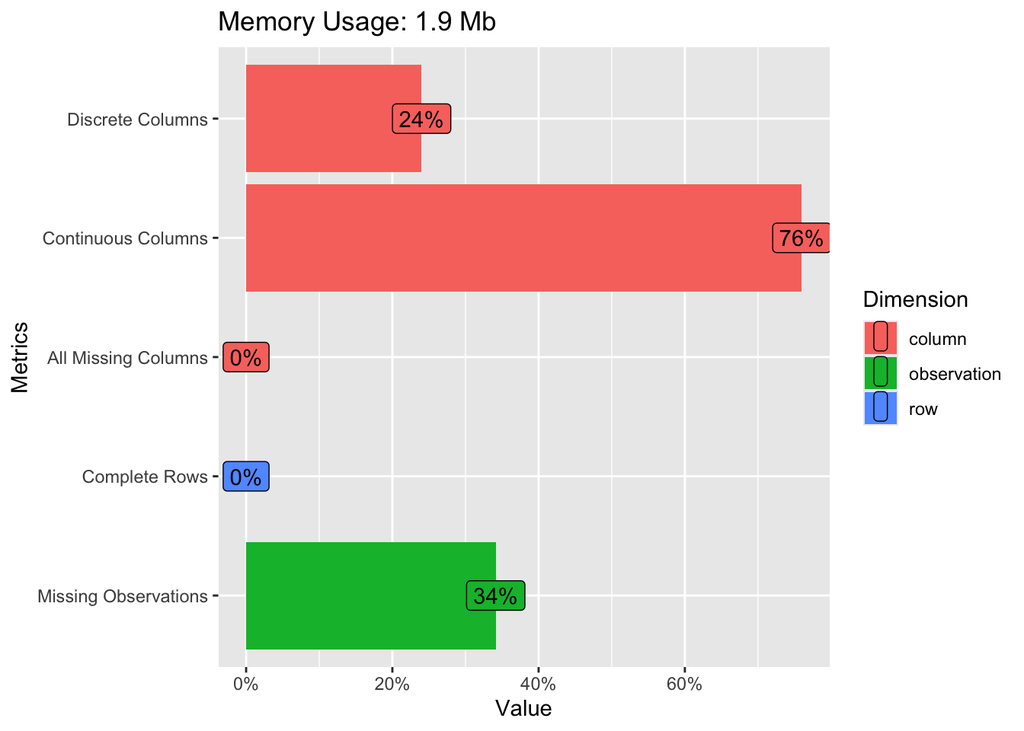

```r
DataExplorer::plot_str(data = data)
DataExplorer::plot_intro(data = data)
```

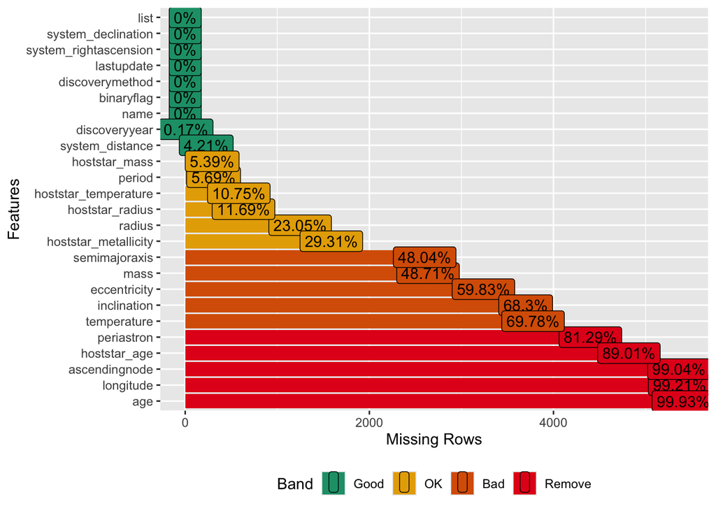

```r
DataExplorer::plot_missing(data = data)
```

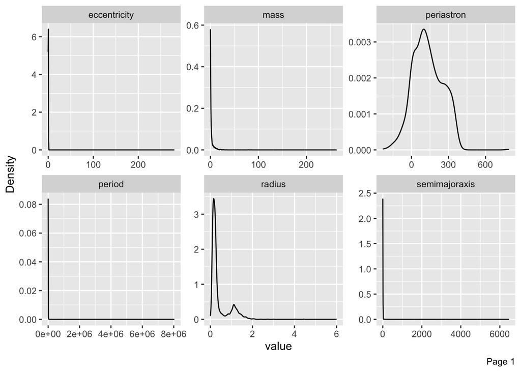

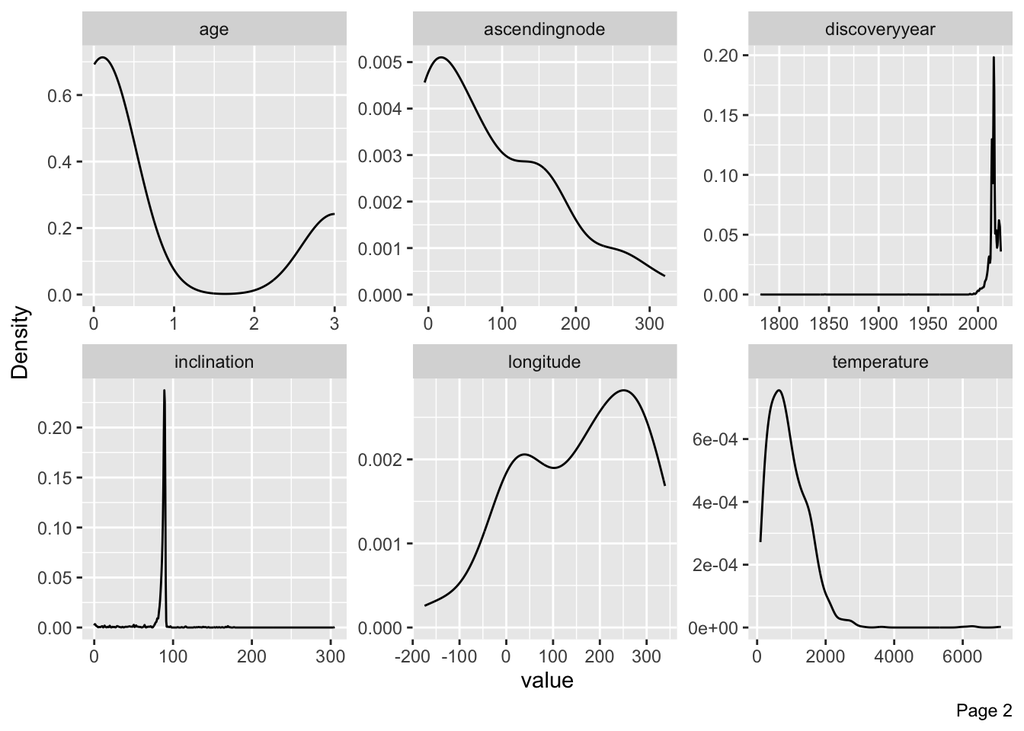

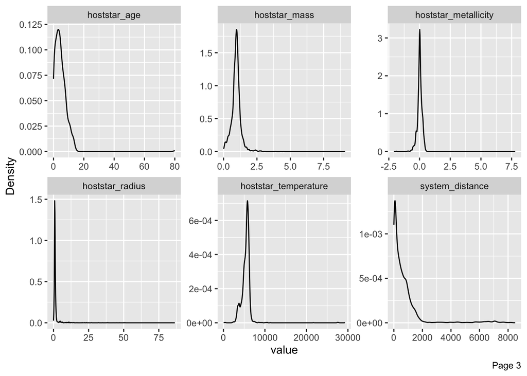

```r
DataExplorer::plot_density(data[,-2],nrow = 2,ncol = 3)
```

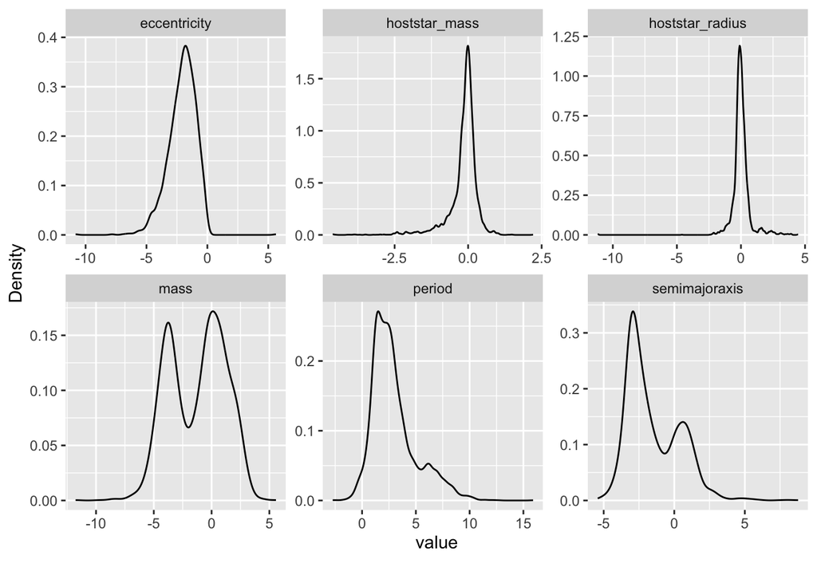

```r
DataExplorer::plot_density(log(data[,c("eccentricity","mass","period","semimajoraxis","hoststar_radius","hoststar_mass")]),nrow = 2,ncol = 3)
```

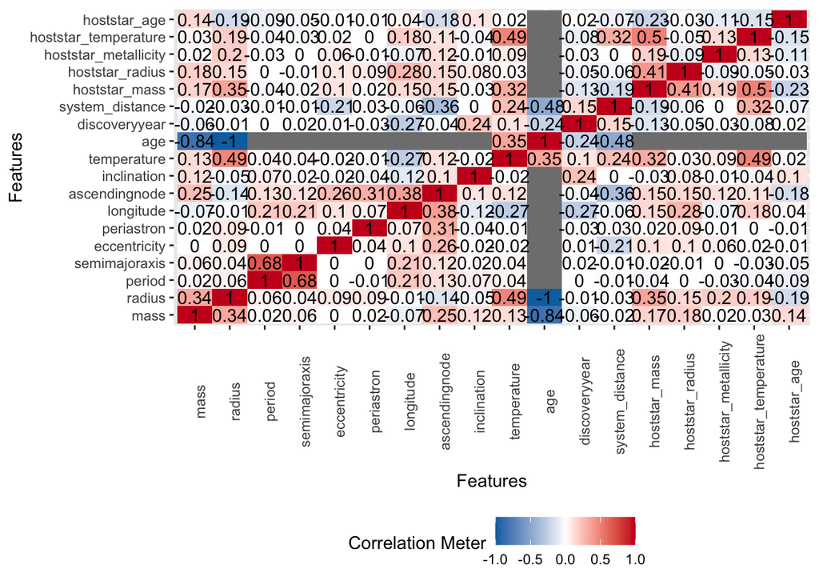

```r
DataExplorer::plot_correlation(data[,-2],type = "continuous",cor_args = list(use = "pairwise.complete.obs", method = "pearson"))
```

# Select relevant columns for analysis

We shall keep 300 observations as a hold out test set and the rest as the training set

```r
data <- data %>% select(semimajoraxis,mass, radius, period, eccentricity, hoststar_mass, hoststar_radius, hoststar_metallicity,hoststar_temperature,binaryflag) %>% na.omit()
summary(data)
```

```
##  semimajoraxis           mass              radius            period
##  Min.   : 0.00916   Min.   : 0.00001   Min.   :0.01644   Min.   :     0.45
##  1st Qu.: 0.04328   1st Qu.: 0.02541   1st Qu.:0.22626   1st Qu.:     3.35
##  Median : 0.06010   Median : 0.27300   Median :0.85600   Median :     5.32
##  Mean   : 0.78890   Mean   : 1.27930   Mean   :0.76944   Mean   :  1047.36
##  3rd Qu.: 0.13000   3rd Qu.: 1.05700   3rd Qu.:1.19000   3rd Qu.:    18.36
##  Max.   :67.96000   Max.   :79.00000   Max.   :2.08500   Max.   :166510.00
##   eccentricity      hoststar_mass   hoststar_radius  hoststar_metallicity
##  Min.   :-0.12929   Min.   :0.089   Min.   : 0.121   Min.   :-0.92000
##  1st Qu.: 0.00000   1st Qu.:0.840   1st Qu.: 0.820   1st Qu.:-0.06000
##  Median : 0.00380   Median :1.000   Median : 1.020   Median : 0.06000
##  Mean   : 0.08658   Mean   :1.001   Mean   : 1.309   Mean   : 0.05242
##  3rd Qu.: 0.10938   3rd Qu.:1.173   3rd Qu.: 1.400   3rd Qu.: 0.18100
##  Max.   : 0.93369   Max.   :2.820   Max.   :86.400   Max.   : 7.79000
##  hoststar_temperature   binaryflag
##  Min.   :2516         Min.   :0.00000
##  1st Qu.:5078         1st Qu.:0.00000
##  Median :5645         Median :0.00000
##  Mean   :5472         Mean   :0.05538
##  3rd Qu.:6000         3rd Qu.:0.00000
##  Max.   :9360         Max.   :2.00000
```

```r
set.seed(1)
te.ind <- sample.int(n = 939,size = 300,replace = F)
data.train = data[-te.ind,]
data.test = data[te.ind,]
```

### Bayesian generalized nonlinear models

We shall use BGNLM with Jeffreys priors for inference run with 32 parallel chains for 20 populations of GMJMCMC algorithm

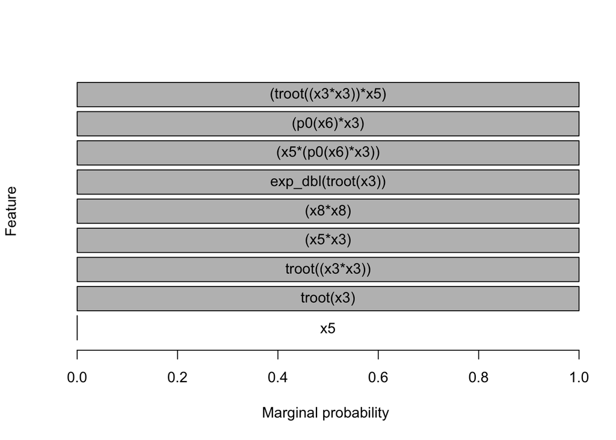

```r
transforms <- c("sin_deg","exp_dbl","p0","troot","p3")
probs <- gen.probs.gmjmcmc(transforms)
params <- gen.params.gmjmcmc(ncol(data.train)-1)
params$loglik$var = "unknown"
set.seed(1)
bgnlm <- FBMS::fbms(semimajoraxis ~ ., data = data.train,method = "gmjmcmc.parallel",beta_prior = list(type = "Jeffreys-BIC"),transforms = transforms,runs = 32,cores = 8,P = 20, probs = probs, params = params)
plot(bgnlm)
```

```r
summary(bgnlm,labels = names(data.train)[-1])
```

| feats.strings | marg.probs |
| --- | --- |
| troot(period) | 1 |
| troot((period*period)) | 1 |
| (hoststar_mass*period) | 1 |
| (hoststar_temperature*hoststar_temperature) | 1 |
| exp_dbl(troot(period)) | 1 |
| (hoststar_mass*(p0(hoststar_radius)*period)) | 1 |
| (p0(hoststar_radius)*period) | 1 |
| (troot((period*period))*hoststar_mass) | 1 |

check convergence

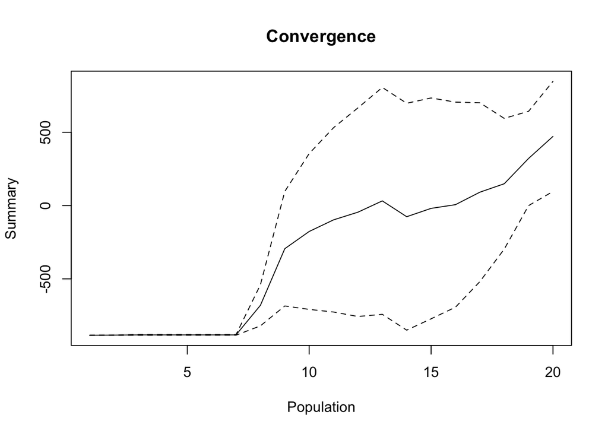

```
## $stat
##  [1] -884.81620 -883.89960 -882.38169 -882.38169 -882.38169 -882.38169
##  [7] -882.38169 -680.50322 -294.15270 -176.70923  -97.41827  -45.03710
## [13]   32.04108  -75.97348  -19.10606    6.24780   91.34202  148.91843
## [19]  321.76253  472.08862
##
## $lower
##  [1] -884.81619993 -885.16992106 -884.79160115 -884.73513805 -884.59622354
##  [6] -884.46096649 -884.34152632 -820.79828528 -684.98335556 -708.35191404
## [11] -726.33929639 -756.87295373 -742.06746405 -850.06493573 -772.57196402
## [16] -693.44268044 -518.93704164 -297.16098239    0.02833879   96.36435725
##
## $upper
##  [1] -884.81620 -882.62927 -879.97177 -880.02823 -880.16715 -880.30241
##  [7] -880.42185 -540.20815   96.67796  354.93346  531.50276  666.79876
## [13]  806.14962  698.11798  734.35984  705.93828  701.62107  594.99783
## [19]  643.49673  847.81288
```

```r
diagn_plot(bgnlm,window = 10,FUN = median)
```

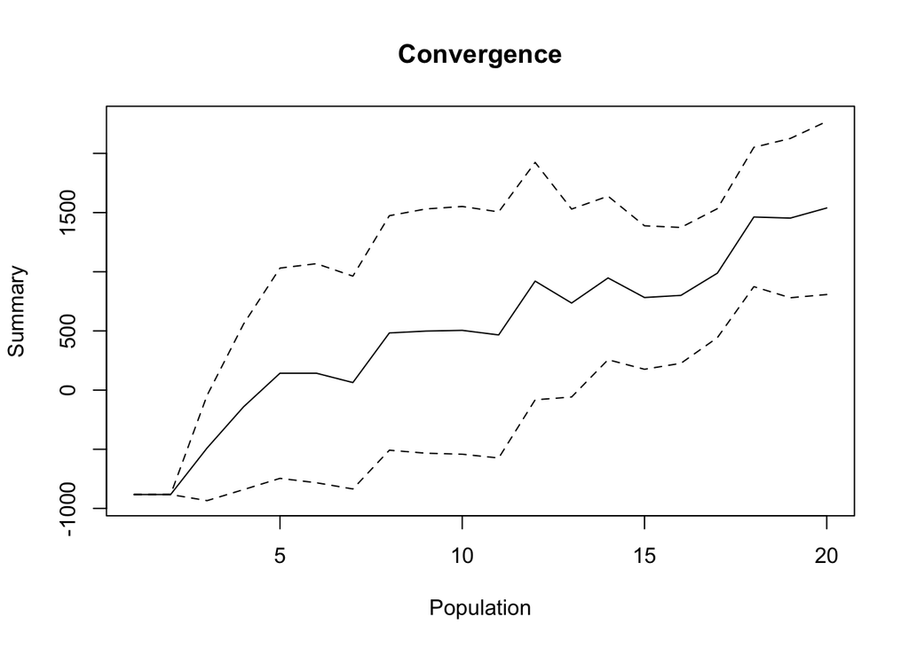

```
## $stat
##  [1] -882.3817 -882.3817 -489.3603 -141.5459  142.6064  142.6064   63.7422
##  [8]  482.8011  498.6948  504.8343  466.0752  920.9319  735.5382  947.6797
## [15]  782.2310  800.3955  988.2343 1462.6631 1453.3230 1538.8436
##
## $lower
##  [1] -882.38169 -882.38169 -934.09770 -840.83975 -745.76847 -782.96107
##  [7] -835.49671 -507.98751 -533.11885 -541.84435 -573.72374  -82.16326
## [13]  -58.43684  256.76436  175.97698  226.45706  443.26045  874.19001
## [19]  780.30672  807.58577
##
## $upper
##  [1] -882.38169 -882.38169  -44.62284  557.74796 1030.98131 1068.17390
##  [7]  962.98111 1473.58974 1530.50848 1551.51296 1505.87415 1924.02714
## [13] 1529.51318 1638.59500 1388.48495 1374.33403 1533.20819 2051.13628
## [19] 2126.33933 2270.10146
```

```r
diagn_plot(bgnlm,window = 10,FUN = max)
```

we see possible convergence for the later generations of GMJMCMC, but let us increase the compute to check if it is indeed so. The limitation of the convergence statistics is that it may show perfect convergence upon algorithm stuck in a good mode and not mixing further across the modes.

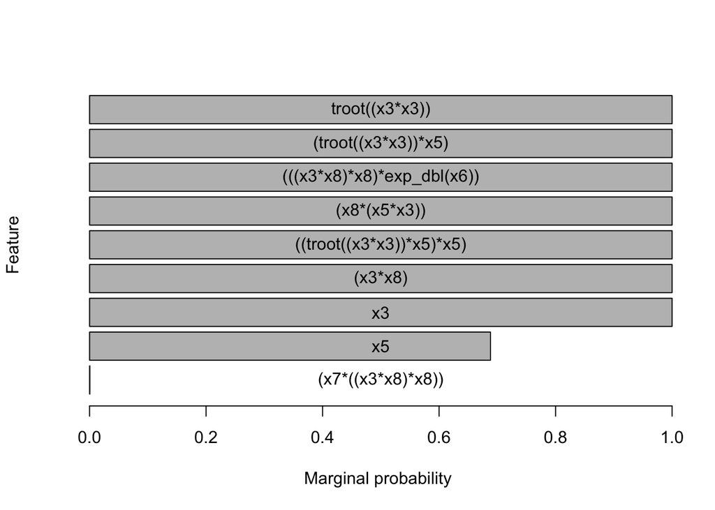

```r
set.seed(2)
bgnlm <- FBMS::fbms(semimajoraxis ~ ., data = data.train,method = "gmjmcmc.parallel",beta_prior = list(type = "Jeffreys-BIC"),transforms = transforms,runs = 64,cores = 8,P = 50,probs = probs, params = params)
plot(bgnlm)
```

```r
summary(bgnlm,labels = names(data.train)[-1])
```

| feats.strings | marg.probs |
| --- | --- |
| (troot((period*period))*hoststar_mass) | 1.0000000000 |
| troot((period*period)) | 1.0000000000 |
| period | 0.9999999999 |
| (period*hoststar_temperature) | 0.9999999999 |
| ((troot((period*period))*hoststar_mass)*hoststar_mass) | 0.9999999999 |
| (hoststar_temperature*(hoststar_mass*period)) | 0.9999999999 |
| (((period*hoststar_temperature)*hoststar_temperature)*exp_dbl(hoststar_radius)) | 0.9999999999 |
| hoststar_mass | 0.6882277119 |
| (hoststar_metallicity*((period*hoststar_temperature)*hoststar_temperature)) | 0.0004389977 |

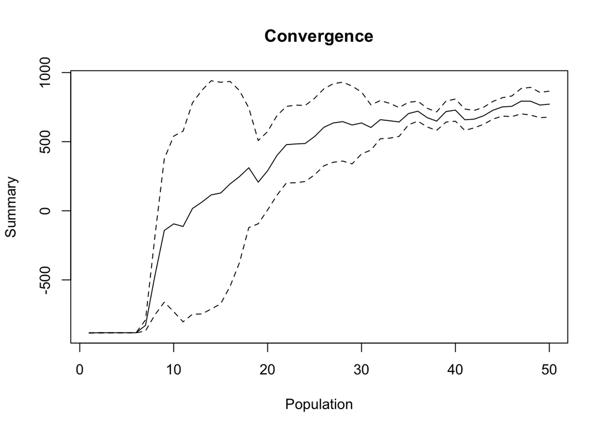

```
## $stat
##  [1] -883.64225 -882.49848 -882.38169 -882.38169 -882.38169 -882.38169
##  [7] -829.01143 -469.99883 -142.35335  -94.78152 -113.62787   16.46003
## [13]   62.53424  115.22367  128.36318  194.11444  247.22784  311.45073
## [19]  206.99075  289.49729  400.92175  478.20407  483.64040  486.75013
## [25]  537.17604  604.28850  635.44155  645.08898  620.56918  635.37806
## [31]  602.64488  659.11711  651.42991  642.67109  703.32754  720.46291
## [37]  673.64550  648.68780  717.93311  728.19768  658.69907  663.12556
## [43]  687.38909  727.53690  751.61024  755.71162  793.10703  792.63353
## [49]  764.97694  771.45571
##
## $lower
##  [1] -883.642247 -884.083631 -883.746845 -883.583715 -883.465545 -883.375861
##  [7] -868.728370 -753.012278 -660.621608 -729.565637 -803.512481 -748.028548
## [13] -746.544179 -710.145331 -673.149505 -547.376872 -376.187440 -121.032737
```

[output cut: 16 more lines]

```r
diagn_plot(bgnlm,window = 10,FUN = median)
```